# MVA Course, Questions 1-5

First we need to import the data we will be using. This is included in the “vegan” package.

```r
library(vegan)# Package for multivariate analyses of ecological data
library(dplyr)
data("dune")
data("dune.env")
#Management factor is character but we need it to be numeric for some analyses. Convert to "dummy" variables...
#If you are converting a factor that is numbers already you need as.numeric(as.character(x))

#give each management method its own column
dummy_management <- as.data.frame(model.matrix( ~ Management - 1, data=dune.env ))
#add these to the dataset
dune.env <- dune.env %>% select(A1, Moisture, Manure, Use) %>% cbind(.,dummy_management)
dune.env$Moisture <- as.numeric(as.character(dune.env$Moisture)) #make numeric
dune.env$Manure <- as.numeric(as.character(dune.env$Manure))
dune.env$Use <- as.numeric(dune.env$Use)
```

#### Question 2: Do a PCA on the environmental data related to the Dune meadow dataset.

What are the results telling you? In what way do objects/samples to the left differ from objects to the right, and at the bottom from those at the top? Which are the most important gradients in the dataset? Which descriptor variables are related, and which are unrelated?

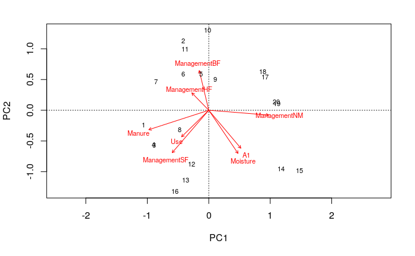

```r
env.pca <- rda(dune.env, scale = TRUE) #vegan uses the same function for PCA and RDA
biplot(env.pca)#plot the results
```

```r
env.pca #summarise results
```

```
Call: rda(X = dune.env, scale = TRUE)

              Inertia Rank
Total               8
Unconstrained       8    7
Inertia is correlations

Eigenvalues for unconstrained axes:
   PC1    PC2    PC3    PC4    PC5    PC6    PC7
2.7348 1.9195 1.3056 1.0477 0.5106 0.4141 0.0677
```

```r
summary(eigenvals(env.pca)) #see variance explained
```

```
Importance of components:
                         PC1    PC2    PC3   PC4     PC5     PC6      PC7
Eigenvalue            2.7348 1.9195 1.3056 1.048 0.51059 0.41413 0.067668
Proportion Explained  0.3418 0.2399 0.1632 0.131 0.06382 0.05177 0.008458
Cumulative Proportion 0.3418 0.5818 0.7450 0.876 0.93977 0.99154 1.000000
```

#### Question 3: For comparison, do also a CA on the Dune Meadow Environmental variables and compare the result with the PCA on the same data!

Why do the results in exercise 2 and 3 differ?

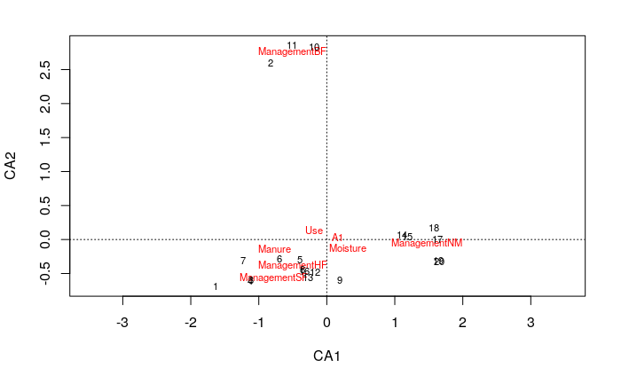

```r
#unconstrained ordination on environmental data (CA)
env.ca <- cca(dune.env) #vegan uses the same function for CA and CCA
plot(env.ca)
```

```r
env.ca
```

```
Call: cca(X = dune.env)

              Inertia Rank
Total          0.4709
Unconstrained  0.4709    7
Inertia is scaled Chi-square

Eigenvalues for unconstrained axes:
    CA1     CA2     CA3     CA4     CA5     CA6     CA7
0.19532 0.11305 0.08393 0.04417 0.02144 0.01081 0.00215
```

```r
summary(eigenvals(env.ca)) #proportion variance explained
```

```
Importance of components:
                         CA1    CA2     CA3     CA4     CA5     CA6      CA7
Eigenvalue            0.1953 0.1130 0.08393 0.04417 0.02144 0.01081 0.002146
Proportion Explained  0.4148 0.2401 0.17825 0.09380 0.04554 0.02295 0.004557
Cumulative Proportion 0.4148 0.6549 0.83315 0.92695 0.97249 0.99544 1.000000
```

#### Question 4: Do a CA-ordination on the Dune Meadow species dataset.What are the results telling you?

Give a conceptual description on why objects/samples and descriptors/species to the left differ from objects and descriptors to the right, and those at the bottom from those at the top! (Plant ecologists may give a more detailed description, using their knowledge about the species in the dataset).

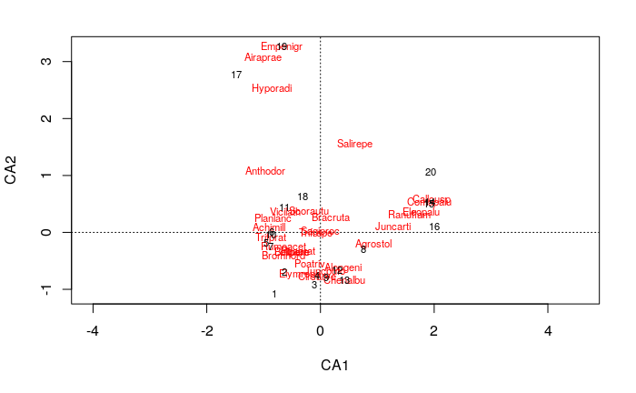

```r
dune.ca <- cca(dune)
plot(dune.ca)
```

```r
dune.ca
```

```
Call: cca(X = dune)

              Inertia Rank
Total           2.115
Unconstrained   2.115   19
Inertia is scaled Chi-square

Eigenvalues for unconstrained axes:
   CA1    CA2    CA3    CA4    CA5    CA6    CA7    CA8
0.5360 0.4001 0.2598 0.1760 0.1448 0.1079 0.0925 0.0809
(Showing 8 of 19 unconstrained eigenvalues)
```

```r
summary(eigenvals(dune.ca)) #proportion variance explained
```

```
Importance of components:
                         CA1    CA2    CA3     CA4     CA5     CA6     CA7     CA8     CA9    CA10    CA11    CA12    CA13
Eigenvalue            0.5360 0.4001 0.2598 0.17598 0.14476 0.10791 0.09247 0.08091 0.07332 0.05630 0.04826 0.04125 0.03523
Proportion Explained  0.2534 0.1892 0.1228 0.08319 0.06844 0.05102 0.04372 0.03825 0.03466 0.02661 0.02282 0.01950 0.01665
Cumulative Proportion 0.2534 0.4426 0.5654 0.64858 0.71702 0.76804 0.81175 0.85000 0.88467 0.91128 0.93410 0.95360 0.97025
                          CA14     CA15     CA16     CA17     CA18     CA19
Eigenvalue            0.020529 0.014911 0.009074 0.007938 0.007002 0.003477
Proportion Explained  0.009705 0.007049 0.004290 0.003753 0.003310 0.001644
Cumulative Proportion 0.979955 0.987004 0.991293 0.995046 0.998356 1.000000
```

#### Question 5: Repeat exercise 4, but with DCA ordination instead.

Look at the eigenvalues, the length of gradient, the total variation and the ordination diagram. Explain the differences between results from CA and DCA.

```r
dune.dca <- decorana(dune)
dune.dca
```

```
Call:
decorana(veg = dune)

Detrended correspondence analysis with 26 segments.
Rescaling of axes with 4 iterations.

                  DCA1   DCA2    DCA3    DCA4
Eigenvalues     0.5117 0.3036 0.12125 0.14267
Decorana values 0.5360 0.2869 0.08136 0.04814
Axis lengths    3.7004 3.1166 1.30055 1.47888
```

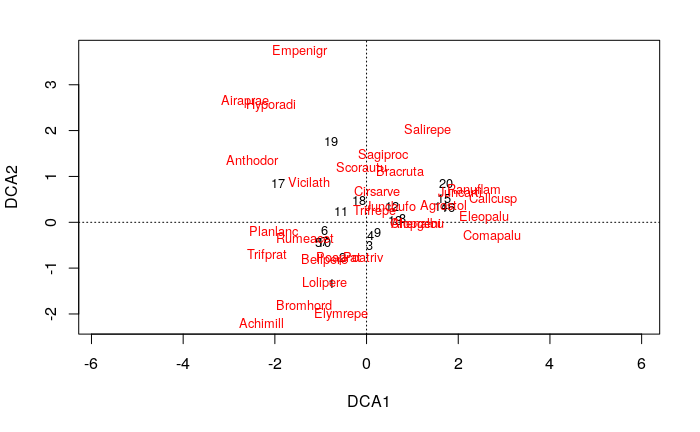

```r
#Detrended correspondence analysis (function decorana).
#The total amount of variation is undefined in detrended
#correspondence analysis and therefore proportions from total
#are unknown and undefined.
#DCA is not a method for decomposition of variation, and therefore
#these proportions would not make sense either.

plot(dune.dca)
```